# Load environment

```python
import pandas as pd
import glob
import seaborn as sns
import matplotlib.pyplot as plt
import yaml
import numpy as np
from collections import defaultdict
from scipy.stats import variation, entropy
```

```python
with open("../data/resources/rcParams.yaml") as f:
    rcParamsDict = yaml.full_load(f)
    for k in rcParamsDict["rcParams"]:
        print("{} {}".format(k,rcParamsDict["rcParams"][k]))
        plt.rcParams[k] = rcParamsDict["rcParams"][k]
    for k1 in set(list(rcParamsDict)).difference(set(["rcParams"])):
        print("{} {}".format(k1,rcParamsDict[k1]))
```

```
figure.dpi 80
savefig.dpi 500
figure.figsize [10, 10]
axes.facecolor None
figure.facecolor None
dotSize 20
```

```python
first_tranche = glob.glob("../../CensusSeq_Feb/output/census/**.txt")
second_tranche = glob.glob("../../CensusSeq_Mar/output/census/**.txt")

all_files = first_tranche + second_tranche
```

```python
color_palette = {
 'CTL01A': '#DBB807',
    'CTL08A': '#0FB248',
    'CTL04E': '#FF0054',
    'CTL02A': '#7B00FF',
'H9': '#72190E',
 'H1': '#994F88',
 'CTL05A': '#1965B0',
 'CTL07C': '#437DBF',
 'CTL06F': '#CAE0AB',
 'CTL09A': '#FFFF00',
 'KTD8_2': '#E65518',
 'UCSFi001-A': '#7BAFDE'}
```

# Load and format data

```python
all_results = {}
for file in all_files:
    name = file.strip('.txt').split('/')[-1].split('.')[0]
    all_results[name] = pd.read_csv(file, skiprows = 2, sep = '\t')
```

```python
all_results_df = pd.concat(all_results.values(), keys = all_results.keys()).reset_index()
donor_map_names = {i:j for i, j in zip(all_results_df['DONOR'], all_results_df['DONOR'])}
donor_map_names['CHD2WT'] = 'UCSFi001-A'
donor_map_names['CHD8WT'] = 'H9'
all_results_df['DONOR'] = all_results_df['DONOR'].map(donor_map_names)

all_results_df.head()
```

|  | level_0 | level_1 | DONOR | REPRESENTATION |
| --- | --- | --- | --- | --- |
| 0 | M18 | 0 | CTL01A | 0.94993 |
| 1 | M18 | 1 | CTL02A | 0.00285 |
| 2 | M18 | 2 | CTL05A | 0.00750 |
| 3 | M18 | 3 | CTL07C | 0.01086 |
| 4 | M18 | 4 | H1 | 0.00647 |

```python
all_results_df.shape
```

```
(582, 4)
```

```python
metadata = pd.read_excel('../../data/csv/CensusSeq_metadata_new.xlsx')
metadata
```

|  | Sample name | Mix | timepoint |
| --- | --- | --- | --- |
| 0 | M1 | 1 | day -2 |
| 1 | M2 | 2 | day -2 |
| 2 | M3 | 3 | day -2 |
| 3 | M4 | 4 | day -2 |
| 4 | M5 | 5 | day -2 |
| ... | ... | ... | ... |
| 90 | M91 | 6 | day 50 |
| 91 | M92 | 6 | day 50 |
| 92 | M93 | 8 | day 50 |
| 93 | M94 | 8 | day 50 |
| 94 | M95 | 8 | day 50 |

95 rows × 3 columns

```python
metadata.index = metadata['Sample name']
```

```python
metadata['Mix'].unique()
```

```
array([1, 2, 3, 4, 5, 6, 7, 8])
```

```python
len(metadata['Sample name'].unique())
```

```
95
```

```python
len(all_results_df['level_0'].unique())
```

```
95
```

```python
all_results_df = all_results_df.drop('level_1', axis  = 1)
all_results_df.columns = ['Sample name', 'DONOR', 'REPRESENTATION']
all_results_df
```

|  | Sample name | DONOR | REPRESENTATION |
| --- | --- | --- | --- |
| 0 | M18 | CTL01A | 0.94993 |
| 1 | M18 | CTL02A | 0.00285 |
| 2 | M18 | CTL05A | 0.00750 |
| 3 | M18 | CTL07C | 0.01086 |
| 4 | M18 | H1 | 0.00647 |
| ... | ... | ... | ... |
| 577 | M60 | H9 | 0.30743 |
| 578 | M60 | CTL04E | 0.01336 |
| 579 | M60 | CTL06F | 0.24393 |
| 580 | M60 | CTL08A | 0.02211 |
| 581 | M60 | CTL09A | 0.40072 |

582 rows × 3 columns

```python
all_results_df.index = all_results_df['Sample name']
all_results_df['MIX ID'] = all_results_df['Sample name'].map({i: j for i, j in zip(metadata['Sample name'], metadata['Mix'])})
all_results_df['Timepoint'] = all_results_df['Sample name'].map({i: j for i, j in zip(metadata['Sample name'], metadata['timepoint'])})
all_results_df = all_results_df[all_results_df['MIX ID'] != 7]
#all_results_df['MIX ID'] = all_results_df['MIX ID'].map({1:1, 2:2, 3:3,4:4,5:5,6:6,8:7})
all_results_df.to_csv('../../data/csv/CensusSeq_data.csv')
```

```python
all_results_df.head()
```

| Sample name | Sample name | DONOR | REPRESENTATION | MIX ID | Timepoint |
| --- | --- | --- | --- | --- | --- |
| M18 | M18 | CTL01A | 0.94993 | 4 | day 5 |
| M18 | M18 | CTL02A | 0.00285 | 4 | day 5 |
| M18 | M18 | CTL05A | 0.00750 | 4 | day 5 |
| M18 | M18 | CTL07C | 0.01086 | 4 | day 5 |
| M18 | M18 | H1 | 0.00647 | 4 | day 5 |

```python
all_results_df.shape
```

```
(546, 5)
```

# Plot contributions from each samples

```python
#color_palette
```

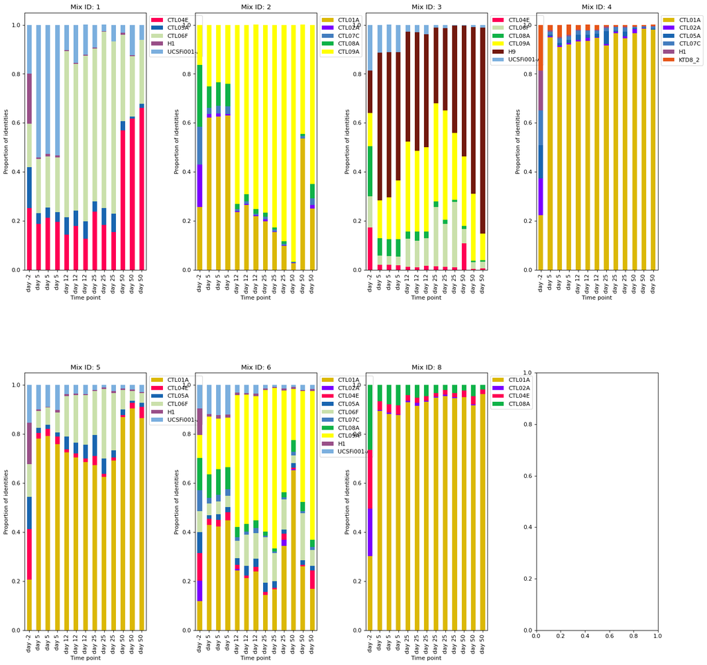

```python
order = ['day -2', 'day 5', 'day 12', 'day 25', 'day 50']
tp = all_results_df['MIX ID'].unique().tolist()
tp.sort()

fig, ax = plt.subplots(2, 4, figsize = (20, 20), gridspec_kw={'wspace': 0.4, 'hspace': 0.4})
ax = ax.flatten().T

for mix, ax in zip(tp, ax):

    sub = all_results_df[all_results_df['MIX ID'] == mix]
    #print(sub)
    sub_df_pivoted = pd.pivot(sub, index = 'Sample name', columns='DONOR', values='REPRESENTATION')

    sub_df_pivoted.index = sub_df_pivoted.index.map({i: j for i, j in zip(sub['Sample name'], sub['Timepoint'])})


    sub_df_pivoted.loc[[i for i in order if i in sub_df_pivoted.index]].plot(kind = 'bar', stacked = True, color = color_palette, ax = ax)
    ax.legend(bbox_to_anchor = (1,1))
    ax.set_title(f'Mix ID: {mix}')
    ax.set_xlabel('Time point')
    ax.set_ylabel('Proportion of identities')
#plt.savefig('censusSeq_results.png')
plt.tight_layout()
plt.show()
```

## Lineplots of contributions trends

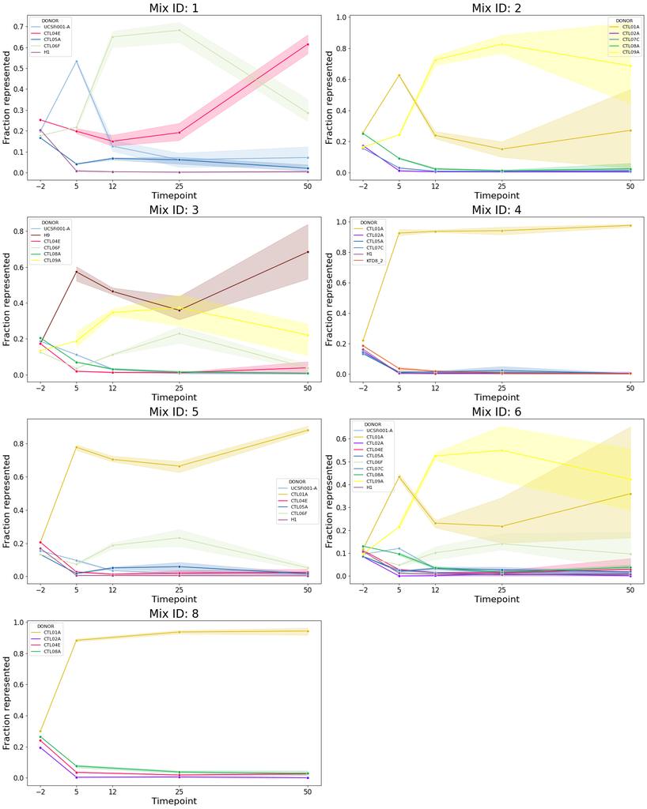

```python
all_results_df['Timepoint_int'] = all_results_df.Timepoint.apply(lambda x: int(x.strip('day ')))
all_results_df['Timepoint_int'].sort_values
mix_ordered = all_results_df['MIX ID'].unique().tolist()
mix_ordered.sort()

fig, ax = plt.subplots(4, 2, figsize = (20, 25))
ax = ax.flatten().T

ax[-1].set_axis_off()

for mix, ax in zip(mix_ordered, ax):

    sub = all_results_df[all_results_df['MIX ID'] == mix].reset_index(drop = True)

    sns.lineplot(data = sub, x = 'Timepoint_int', y = 'REPRESENTATION', hue = 'DONOR', marker = 'o', palette=color_palette, ax = ax)

    ax.set_title(f'Mix ID: {mix}', fontsize = 25)
    ax.set_ylabel('Fraction represented', fontsize = 20)
    ax.set_xlabel('Timepoint', fontsize = 20)
    #start, end = (-3, 52)
    ax.xaxis.set_ticks([-2, 5, 12, 25, 50])

    ax.tick_params(axis='both', labelsize=15)


plt.tight_layout()
plt.savefig('./figures/Mix_CensusSeq.svg', bbox_inches = 'tight')
```

```python
all_results_df = all_results_df.drop('Sample name', axis = 1).reset_index()
max_rep = all_results_df[all_results_df.Timepoint == 'day 5'].groupby('Sample name').max('REPRESENTATION')['REPRESENTATION']
all_results_df[all_results_df.Timepoint == 'day 5'][all_results_df[all_results_df.Timepoint == 'day 5'].REPRESENTATION.isin(max_rep)]
```

|  | Sample name | DONOR | REPRESENTATION | MIX ID | Timepoint | Timepoint_int |
| --- | --- | --- | --- | --- | --- | --- |
| 0 | M18 | CTL01A | 0.94993 | 4 | day 5 | 5 |
| 28 | M19 | CTL01A | 0.91013 | 4 | day 5 | 5 |
| 56 | M23 | CTL01A | 0.75915 | 5 | day 5 | 5 |
| 95 | M30 | CTL01A | 0.89443 | 8 | day 5 | 5 |
| 112 | M31 | CTL01A | 0.88202 | 8 | day 5 | 5 |
| 143 | M22 | CTL01A | 0.79156 | 5 | day 5 | 5 |
| 159 | M10 | UCSFi001-A | 0.54225 | 1 | day 5 | 5 |
| 191 | M21 | CTL01A | 0.78139 | 5 | day 5 | 5 |
| 206 | M20 | CTL01A | 0.91905 | 4 | day 5 | 5 |
| 217 | M32 | CTL01A | 0.87633 | 8 | day 5 | 5 |
| 253 | M11 | UCSFi001-A | 0.52613 | 1 | day 5 | 5 |
| 262 | M9 | UCSFi001-A | 0.53311 | 1 | day 5 | 5 |
| 273 | M12 | CTL01A | 0.62220 | 2 | day 5 | 5 |
| 311 | M25 | CTL01A | 0.42265 | 6 | day 5 | 5 |
| 331 | M26 | CTL01A | 0.44736 | 6 | day 5 | 5 |
| 367 | M17 | H9 | 0.52285 | 3 | day 5 | 5 |
| 372 | M14 | CTL01A | 0.62952 | 2 | day 5 | 5 |
| 377 | M13 | CTL01A | 0.62534 | 2 | day 5 | 5 |
| 430 | M16 | H9 | 0.59398 | 3 | day 5 | 5 |
| 442 | M24 | CTL01A | 0.42961 | 6 | day 5 | 5 |
| 529 | M15 | H9 | 0.60331 | 3 | day 5 | 5 |

```python
all_results_df.Timepoint.unique()
```

```
array(['day 5', 'day 12', 'day 25', 'day 50', 'day -2'], dtype=object)
```

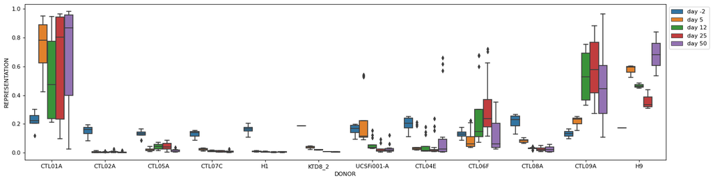

```python
fig, ax = plt.subplots(figsize = (20,5))
sns.boxplot(data = all_results_df, x = 'DONOR', y = 'REPRESENTATION', hue = 'Timepoint', hue_order=['day -2', 'day 5', 'day 12', 'day 25', 'day 50'])
ax.legend(bbox_to_anchor = (1,1))
```

# Compute entropy of representations

[Shannon's entropy](https://docs.scipy.org/doc/scipy/reference/generated/scipy.stats.entropy.html) is computed for each timepoint and each sample. It quantifies the expected uncertainty inherent in the possible outcomes of a discrete random variable, therefore the higher its value and and the higher the balance in representation. In fact, we observe a higher entropy for -2 time point.

```python
entropy_df = all_results_df.groupby(['Timepoint_int', 'Sample name'])['REPRESENTATION'].apply(entropy).reset_index()
entropy_df.head()
```

|  | Timepoint_int | Sample name | REPRESENTATION |
| --- | --- | --- | --- |
| 0 | -2 | M1 | 1.598650 |
| 1 | -2 | M2 | 1.584976 |
| 2 | -2 | M3 | 1.777457 |
| 3 | -2 | M4 | 1.776391 |
| 4 | -2 | M5 | 1.775167 |

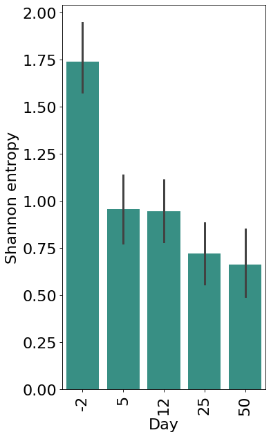

```python
fig, ax = plt.subplots(figsize = (5,8))
sns.barplot(data = entropy_df, x = 'Timepoint_int', y = 'REPRESENTATION', ax = ax, color = '#2a9d8f')
#sns.swarmplot(data = std, x = 'MIX ID', y = 'REPRESENTATION', hue = 'Timepoint_int', ax = ax, dodge = True)
ax.set_xticklabels(ax.get_xticklabels(), rotation = 90)

ax.set_ylabel('Shannon entropy', fontsize = 20)
ax.set_xlabel('Day', fontsize = 20)
ax.tick_params(axis='both', which='major', labelsize=20)

#plt.legend(bbox_to_anchor = (1,1), title = 'Day')
plt.tight_layout()
plt.savefig('./figures/Entropy.svg', bbox_inches = 'tight')
```

# Compute coefficient of variation of representations for each donor

[Coefficient of variation](https://docs.scipy.org/doc/scipy/reference/generated/scipy.stats.variation.html#scipy.stats.variation) is computed for **each timepoint and each donor** (so variation for each donor at a certain time point across different mixes). Time point -2 is excluded because no replicate i available for that.  
Additionally, for each donor the absolute difference in CV between one time point and the previous one is computed.

```python
std = all_results_df.groupby(['Timepoint_int', 'DONOR'])['REPRESENTATION'].apply(variation).reset_index()
std = std[std.Timepoint_int != -2]

std = std.sort_values(by=["DONOR", "Timepoint_int"])
std["Difference"] = std.groupby("DONOR")["REPRESENTATION"].diff()
#std
```

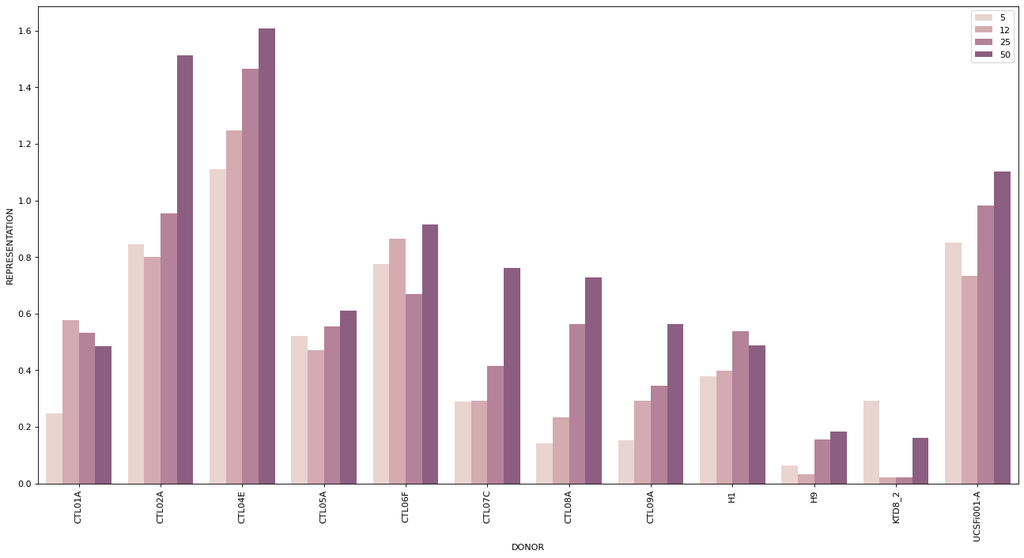

```python
fig, ax = plt.subplots(figsize = (20,10))
sns.barplot(data = std, x = 'DONOR', y = 'REPRESENTATION', hue = 'Timepoint_int', ax = ax, palette = sns.cubehelix_palette())
ax.set_xticklabels(ax.get_xticklabels(), rotation = 90)
plt.legend(bbox_to_anchor = (1,1))
plt.savefig('./figures/CV_timepoint_donor.svg', bbox_inches = 'tight')
```

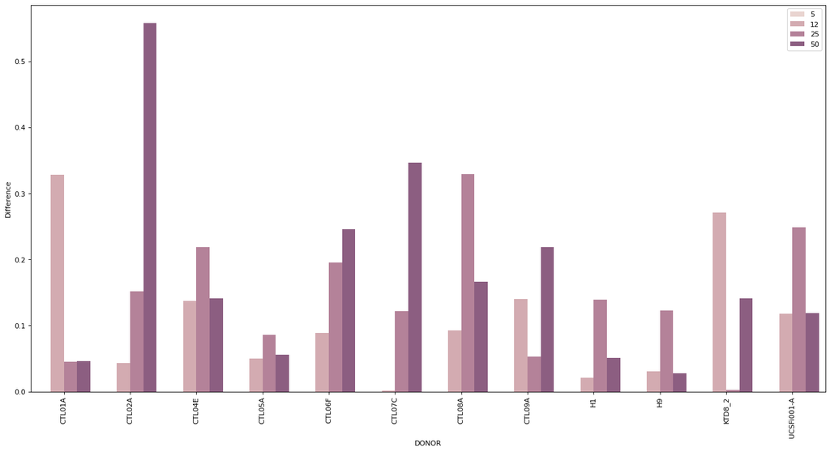

```python
fig, ax = plt.subplots(figsize = (20,10))
std['Difference'] = np.abs(std['Difference'])
sns.barplot(data = std, x = 'DONOR', y = 'Difference', hue = 'Timepoint_int', ax = ax, palette = sns.cubehelix_palette())
ax.set_xticklabels(ax.get_xticklabels(), rotation = 90)
plt.legend(bbox_to_anchor = (1,1))
```

# Compute coefficient of variation the of representations for each donor in each mix

```python
std = all_results_df.groupby(['Timepoint_int', 'MIX ID', 'DONOR'])['REPRESENTATION'].apply(variation).reset_index()
std = std[std.Timepoint_int != -2]

std = std.sort_values(by=["MIX ID", 'DONOR', "Timepoint_int"])
std["Difference"] = std.groupby("MIX ID")["REPRESENTATION"].diff()
std
```

|  | Timepoint_int | MIX ID | DONOR | REPRESENTATION | Difference |
| --- | --- | --- | --- | --- | --- |
| 42 | 5 | 1 | CTL04E | 0.050608 | NaN |
| 84 | 12 | 1 | CTL04E | 0.144417 | 0.093809 |
| 122 | 25 | 1 | CTL04E | 0.178294 | 0.033876 |
| 164 | 50 | 1 | CTL04E | 0.060064 | -0.118230 |
| 43 | 5 | 1 | CTL05A | 0.036617 | -0.023446 |
| ... | ... | ... | ... | ... | ... |
| 162 | 25 | 8 | CTL04E | 0.134457 | 0.091223 |
| 204 | 50 | 8 | CTL04E | 0.240799 | 0.106342 |
| 83 | 5 | 8 | CTL08A | 0.100209 | -0.140590 |
| 163 | 25 | 8 | CTL08A | 0.263623 | 0.163414 |
| 205 | 50 | 8 | CTL08A | 0.416809 | 0.153186 |

164 rows × 5 columns

We plot here the distribution of the CV in each mix for each timepoint (each point of the distribution would be a donor)

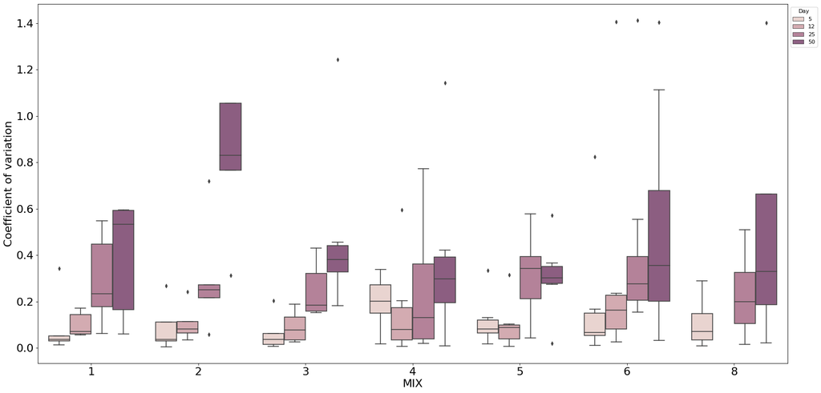

```python
fig, ax = plt.subplots(figsize = (20,10))
sns.boxplot(data = std, x = 'MIX ID', y = 'REPRESENTATION', hue = 'Timepoint_int', ax = ax, palette = sns.cubehelix_palette())
#ax.set_xticklabels(ax.get_xticklabels(), rotation = 90)
ax.set_ylabel('Coefficient of variation', fontsize = 20)
ax.set_xlabel('MIX', fontsize = 20)

ax.tick_params(axis='both', which='major', labelsize=20)
plt.tight_layout()
plt.legend(bbox_to_anchor = (1,1), title = 'Day')
plt.savefig('./figures/CV_timepoint_mix_donor.svg', bbox_inches = 'tight')
```

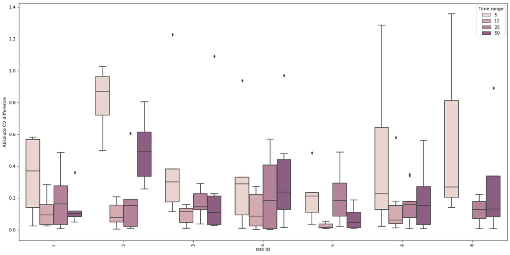

```python
std['Difference'] = np.abs(std['Difference'])

fig, ax = plt.subplots(figsize = (20,10))
sns.boxplot(data = std, x = 'MIX ID', y = 'Difference', hue = 'Timepoint_int', ax = ax, palette = sns.cubehelix_palette())
ax.set_xticklabels(ax.get_xticklabels(), rotation = 90)
ax.set_ylabel('Absolute CV difference')
plt.legend(bbox_to_anchor = (1,1), title = 'Time range')
```

# Compute weighted rank and weighted normalized rank

## Day 5

```python
all_timepoints_norm_weighted = {}
```

```python
ranked_lists = {}
for m in all_results_df[all_results_df['Timepoint'] == 'day 5']['MIX ID'].unique():
    df = all_results_df[((all_results_df['Timepoint'] == 'day 5') & (all_results_df['MIX ID'] == m)  )].sort_values(by = 'REPRESENTATION', ascending = False)
    #print(df.groupby('DONOR').sum().sort_values(by = 'REPRESENTATION', ascending = False))
    result = df.groupby('DONOR').sum().sort_values(by = 'REPRESENTATION', ascending = False).reset_index()
    ranked_lists[f'Mix {m}'] = result.DONOR.tolist()
```

```python
ranked_lists
```

```
{'Mix 4': ['CTL01A', 'KTD8_2', 'CTL07C', 'CTL05A', 'H1', 'CTL02A'],
 'Mix 5': ['CTL01A', 'UCSFi001-A', 'CTL06F', 'CTL04E', 'CTL05A', 'H1'],
 'Mix 8': ['CTL01A', 'CTL08A', 'CTL04E', 'CTL02A'],
 'Mix 1': ['UCSFi001-A', 'CTL06F', 'CTL04E', 'CTL05A', 'H1'],
 'Mix 2': ['CTL01A', 'CTL09A', 'CTL08A', 'CTL07C', 'CTL02A'],
 'Mix 6': ['CTL01A',
  'CTL09A',
  'UCSFi001-A',
  'CTL08A',
  'CTL06F',
  'CTL04E',
  'CTL07C',
  'CTL05A',
  'H1',
  'CTL02A'],
 'Mix 3': ['H9', 'CTL09A', 'UCSFi001-A', 'CTL08A', 'CTL06F', 'CTL04E']}
```

```python
data = list(ranked_lists.values())
```

### Weighted mean - not including percentages

```python
d = defaultdict(list)
d

for l in data:
    #print(len(l))
    for idx, value in enumerate(l):
        d[value].append( (idx + 1) * len(l)) # or (idx + 1) * len(l)? which one is better?
```

```python
mean_d = {}
for l in d:
    mean_d[l] = np.mean(d[l])
```

```python
mean_d_df = pd.DataFrame(mean_d.values(), mean_d.keys())
mean_d_df.columns = ['mean_weighted_rank']
#mean_d_df = mean_d_df.drop(1)
mean_d_df.sort_values(by = 'mean_weighted_rank', ascending = True)
```

|  | mean_weighted_rank |
| --- | --- |
| H9 | 6.00 |
| CTL01A | 6.20 |
| KTD8_2 | 12.00 |
| CTL09A | 14.00 |
| UCSFi001-A | 16.25 |
| CTL08A | 21.75 |
| CTL06F | 27.00 |
| CTL04E | 29.40 |
| CTL07C | 36.00 |
| CTL05A | 38.50 |
| CTL02A | 44.25 |
| H1 | 45.25 |

```python
mean_d_df.sort_values(by = 'mean_weighted_rank').to_csv('../../data/csv/CensusSeq_weighted_rank_d5.csv')
```

### Weighted mean - including percentages

```python
all_results_df[(all_results_df['Timepoint'] == 'day 5')].groupby('DONOR').sum('REPRESENTATION').sort_values(by = 'REPRESENTATION')
```

| DONOR | REPRESENTATION | MIX ID | Timepoint_int |
| --- | --- | --- | --- |
| CTL02A | 0.06150 | 60 | 60 |
| H1 | 0.10079 | 48 | 60 |
| KTD8_2 | 0.11159 | 12 | 15 |
| CTL07C | 0.21065 | 36 | 45 |
| CTL05A | 0.27002 | 48 | 60 |
| CTL04E | 0.92864 | 69 | 75 |
| CTL08A | 1.00095 | 57 | 60 |
| CTL06F | 1.12763 | 45 | 60 |
| H9 | 1.72014 | 9 | 15 |
| CTL09A | 1.93780 | 33 | 45 |
| UCSFi001-A | 2.58963 | 45 | 60 |
| CTL01A | 10.94067 | 75 | 75 |

```python
mean_d_df['mean_Representation'] = all_results_df[(all_results_df['Timepoint'] == 'day 5')].groupby('DONOR').mean('REPRESENTATION')['REPRESENTATION']
mean_d_df['combined_scores'] = mean_d_df['mean_weighted_rank'] * mean_d_df['mean_Representation']
mean_d_df.sort_values('combined_scores')
```

|  | mean_weighted_rank | mean_Representation | combined_scores |
| --- | --- | --- | --- |
| CTL02A | 44.25 | 0.005125 | 0.226781 |
| H1 | 45.25 | 0.008399 | 0.380062 |
| KTD8_2 | 12.00 | 0.037197 | 0.446360 |
| CTL07C | 36.00 | 0.023406 | 0.842600 |
| CTL05A | 38.50 | 0.022502 | 0.866314 |
| CTL08A | 21.75 | 0.083413 | 1.814222 |
| CTL04E | 29.40 | 0.061909 | 1.820134 |
| CTL06F | 27.00 | 0.093969 | 2.537167 |
| CTL09A | 14.00 | 0.215311 | 3.014356 |
| H9 | 6.00 | 0.573380 | 3.440280 |
| UCSFi001-A | 16.25 | 0.215802 | 3.506791 |
| CTL01A | 6.20 | 0.729378 | 4.522144 |

```python
mean_d_df.sort_values('combined_scores').to_csv('../../data/csv/CensusSeq_combined_weighted_rank_d5.csv')
```

```python
np.round(mean_d_df.sort_values('combined_scores'), 2)
```

|  | mean_weighted_rank | mean_Representation | combined_scores |
| --- | --- | --- | --- |
| CTL02A | 44.25 | 0.01 | 0.23 |
| H1 | 45.25 | 0.01 | 0.38 |
| KTD8_2 | 12.00 | 0.04 | 0.45 |
| CTL07C | 36.00 | 0.02 | 0.84 |
| CTL05A | 38.50 | 0.02 | 0.87 |
| CTL08A | 21.75 | 0.08 | 1.81 |
| CTL04E | 29.40 | 0.06 | 1.82 |
| CTL06F | 27.00 | 0.09 | 2.54 |
| CTL09A | 14.00 | 0.22 | 3.01 |
| H9 | 6.00 | 0.57 | 3.44 |
| UCSFi001-A | 16.25 | 0.22 | 3.51 |
| CTL01A | 6.20 | 0.73 | 4.52 |

```python
all_timepoints_norm_weighted['day 5'] = mean_d_df['combined_scores']
```

## Day 12

```python
ranked_lists = {}
for m in all_results_df[all_results_df['Timepoint'] == 'day 12']['MIX ID'].unique():
    df = all_results_df[((all_results_df['Timepoint'] == 'day 12') & (all_results_df['MIX ID'] == m)  )].sort_values(by = 'REPRESENTATION', ascending = False)
    result = df.groupby('DONOR').sum().sort_values(by = 'REPRESENTATION', ascending = False).reset_index()
    ranked_lists[f'Mix {m}'] = result.DONOR.tolist()
```

```python
data = list(ranked_lists.values())
```

### Weighted mean - not including percentages

```python
d = defaultdict(list)
d

for l in data:
    for idx, value in enumerate(l):
        d[value].append( (idx + 1) * len(l)) # or (idx + 1) * len(l)? which one is better?
```

```python
mean_d = {}
for l in d:
    mean_d[l] = np.mean(d[l])
```

```python
mean_d_df = pd.DataFrame(mean_d.values(), mean_d.keys())
mean_d_df.columns = ['mean_weighted_rank']
mean_d_df.sort_values(by = 'mean_weighted_rank', ascending = True)
```

|  | mean_weighted_rank |
| --- | --- |
| H9 | 6.000000 |
| CTL09A | 9.000000 |
| CTL01A | 10.500000 |
| KTD8_2 | 12.000000 |
| CTL06F | 16.250000 |
| CTL05A | 26.500000 |
| CTL08A | 28.333333 |
| UCSFi001-A | 30.750000 |
| CTL04E | 36.500000 |
| CTL07C | 41.333333 |
| H1 | 46.750000 |
| CTL02A | 51.666667 |

### Weighted mean - including percentages

```python
all_results_df[(all_results_df['Timepoint'] == 'day 12')].groupby('DONOR').sum('REPRESENTATION').sort_values(by = 'REPRESENTATION')
```

| DONOR | REPRESENTATION | MIX ID | Timepoint_int |
| --- | --- | --- | --- |
| CTL02A | 0.03948 | 36 | 108 |
| KTD8_2 | 0.06124 | 12 | 36 |
| H1 | 0.06882 | 48 | 144 |
| CTL07C | 0.11447 | 36 | 108 |
| CTL08A | 0.26965 | 33 | 108 |
| CTL05A | 0.50789 | 48 | 144 |
| CTL04E | 0.57805 | 45 | 144 |
| UCSFi001-A | 0.68447 | 45 | 144 |
| H9 | 1.39503 | 9 | 36 |
| CTL06F | 3.15496 | 45 | 144 |
| CTL09A | 4.78777 | 33 | 108 |
| CTL01A | 6.33816 | 51 | 144 |

```python
mean_d_df['mean_Representation'] = all_results_df[(all_results_df['Timepoint'] == 'day 12')].groupby('DONOR').mean('REPRESENTATION')['REPRESENTATION']
mean_d_df['combined_scores'] = mean_d_df['mean_weighted_rank'] * mean_d_df['mean_Representation']
mean_d_df.sort_values('combined_scores')
```

|  | mean_weighted_rank | mean_Representation | combined_scores |
| --- | --- | --- | --- |
| CTL02A | 51.666667 | 0.004387 | 0.226644 |
| KTD8_2 | 12.000000 | 0.020413 | 0.244960 |
| H1 | 46.750000 | 0.005735 | 0.268111 |
| CTL07C | 41.333333 | 0.012719 | 0.525714 |
| CTL08A | 28.333333 | 0.029961 | 0.848898 |
| CTL05A | 26.500000 | 0.042324 | 1.121590 |
| UCSFi001-A | 30.750000 | 0.057039 | 1.753954 |
| CTL04E | 36.500000 | 0.048171 | 1.758235 |
| H9 | 6.000000 | 0.465010 | 2.790060 |
| CTL06F | 16.250000 | 0.262913 | 4.272342 |
| CTL09A | 9.000000 | 0.531974 | 4.787770 |
| CTL01A | 10.500000 | 0.528180 | 5.545890 |

```python
mean_d_df.sort_values('combined_scores').to_csv('../../data/csv/CensusSeq_combined_weighted_rank_d12.csv')
```

```python
np.round(mean_d_df.sort_values('combined_scores'), 2)
```

|  | mean_weighted_rank | mean_Representation | combined_scores |
| --- | --- | --- | --- |
| CTL02A | 51.67 | 0.00 | 0.23 |
| KTD8_2 | 12.00 | 0.02 | 0.24 |
| H1 | 46.75 | 0.01 | 0.27 |
| CTL07C | 41.33 | 0.01 | 0.53 |
| CTL08A | 28.33 | 0.03 | 0.85 |
| CTL05A | 26.50 | 0.04 | 1.12 |
| UCSFi001-A | 30.75 | 0.06 | 1.75 |
| CTL04E | 36.50 | 0.05 | 1.76 |
| H9 | 6.00 | 0.47 | 2.79 |
| CTL06F | 16.25 | 0.26 | 4.27 |
| CTL09A | 9.00 | 0.53 | 4.79 |
| CTL01A | 10.50 | 0.53 | 5.55 |

```python
all_timepoints_norm_weighted['day 12'] = mean_d_df['combined_scores']
```

## Day 25

```python
ranked_lists = {}
for m in all_results_df[all_results_df['Timepoint'] == 'day 25']['MIX ID'].unique():
    df = all_results_df[((all_results_df['Timepoint'] == 'day 25') & (all_results_df['MIX ID'] == m)  )].sort_values(by = 'REPRESENTATION', ascending = False)
    result = df.groupby('DONOR').sum().sort_values(by = 'REPRESENTATION', ascending = False).reset_index()
    ranked_lists[f'Mix {m}'] = result.DONOR.tolist()
```

```python
data = list(ranked_lists.values())
```

### Weighted mean - not including percentages

```python
d = defaultdict(list)
d

for l in data:
    for idx, value in enumerate(l):
        d[value].append( (idx + 1) * len(l)) # or (idx + 1) * len(l)? which one is better?
```

```python
mean_d = {}
for l in d:
    mean_d[l] = np.mean(d[l])
```

```python
mean_d_df = pd.DataFrame(mean_d.values(), mean_d.keys())
mean_d_df.columns = ['mean_weighted_rank']
mean_d_df.sort_values(by = 'mean_weighted_rank', ascending = True)
```

|  | mean_weighted_rank |
| --- | --- |
| CTL09A | 7.000000 |
| CTL01A | 9.200000 |
| H9 | 12.000000 |
| CTL06F | 16.250000 |
| CTL05A | 22.500000 |
| KTD8_2 | 24.000000 |
| CTL08A | 24.250000 |
| CTL04E | 27.200000 |
| CTL02A | 37.750000 |
| UCSFi001-A | 37.750000 |
| CTL07C | 42.666667 |
| H1 | 49.250000 |

### Weighted mean - including percentages

```python
all_results_df[(all_results_df['Timepoint'] == 'day 25')].groupby('DONOR').sum('REPRESENTATION').sort_values(by = 'REPRESENTATION')
```

| DONOR | REPRESENTATION | MIX ID | Timepoint_int |
| --- | --- | --- | --- |
| KTD8_2 | 0.02428 | 12 | 75 |
| H1 | 0.05101 | 48 | 300 |
| CTL07C | 0.08319 | 36 | 225 |
| CTL02A | 0.09660 | 84 | 375 |
| UCSFi001-A | 0.31279 | 45 | 300 |
| CTL08A | 0.35909 | 81 | 375 |
| CTL05A | 0.51931 | 48 | 300 |
| CTL04E | 0.82397 | 93 | 450 |
| H9 | 1.07928 | 9 | 75 |
| CTL06F | 3.85586 | 45 | 300 |
| CTL09A | 5.24697 | 33 | 225 |
| CTL01A | 11.54762 | 99 | 450 |

```python
mean_d_df['mean_Representation'] = all_results_df[(all_results_df['Timepoint'] == 'day 25')].groupby('DONOR').mean('REPRESENTATION')['REPRESENTATION']
mean_d_df['combined_scores'] = mean_d_df['mean_weighted_rank'] * mean_d_df['mean_Representation']
mean_d_df.sort_values('combined_scores')
```

|  | mean_weighted_rank | mean_Representation | combined_scores |
| --- | --- | --- | --- |
| KTD8_2 | 24.000000 | 0.008093 | 0.194240 |
| H1 | 49.250000 | 0.004251 | 0.209354 |
| CTL02A | 37.750000 | 0.006440 | 0.243110 |
| CTL07C | 42.666667 | 0.009243 | 0.394382 |
| CTL08A | 24.250000 | 0.023939 | 0.580529 |
| CTL05A | 22.500000 | 0.043276 | 0.973706 |
| UCSFi001-A | 37.750000 | 0.026066 | 0.983985 |
| CTL04E | 27.200000 | 0.045776 | 1.245110 |
| CTL09A | 7.000000 | 0.582997 | 4.080977 |
| H9 | 12.000000 | 0.359760 | 4.317120 |
| CTL06F | 16.250000 | 0.321322 | 5.221477 |
| CTL01A | 9.200000 | 0.641534 | 5.902117 |

```python
np.round(mean_d_df.sort_values('combined_scores'), 2)
```

|  | mean_weighted_rank | mean_Representation | combined_scores |
| --- | --- | --- | --- |
| KTD8_2 | 24.00 | 0.01 | 0.19 |
| H1 | 49.25 | 0.00 | 0.21 |
| CTL02A | 37.75 | 0.01 | 0.24 |
| CTL07C | 42.67 | 0.01 | 0.39 |
| CTL08A | 24.25 | 0.02 | 0.58 |
| CTL05A | 22.50 | 0.04 | 0.97 |
| UCSFi001-A | 37.75 | 0.03 | 0.98 |
| CTL04E | 27.20 | 0.05 | 1.25 |
| CTL09A | 7.00 | 0.58 | 4.08 |
| H9 | 12.00 | 0.36 | 4.32 |
| CTL06F | 16.25 | 0.32 | 5.22 |
| CTL01A | 9.20 | 0.64 | 5.90 |

```python
mean_d_df.sort_values('combined_scores').to_csv('../../data/csv/CensusSeq_combined_weighted_rank_d25.csv')
```

```python
all_timepoints_norm_weighted['day 25'] = mean_d_df['combined_scores']
```

## Day 50

```python
ranked_lists = {}
for m in all_results_df[all_results_df['Timepoint'] == 'day 50']['MIX ID'].unique():
    df = all_results_df[((all_results_df['Timepoint'] == 'day 50') & (all_results_df['MIX ID'] == m)  )].sort_values(by = 'REPRESENTATION', ascending = False)
    result = df.groupby('DONOR').sum().sort_values(by = 'REPRESENTATION', ascending = False).reset_index()
    ranked_lists[f'Mix {m}'] = result.DONOR.tolist()
```

```python
data = list(ranked_lists.values())
```

### Weighted mean - not including percentages

```python
d = defaultdict(list)
d

for l in data:
    for idx, value in enumerate(l):
        d[value].append( (idx + 1) * len(l)) # or (idx + 1) * len(l)? which one is better?
```

```python
mean_d = {}
for l in d:
    mean_d[l] = np.mean(d[l])
```

```python
mean_d_df = pd.DataFrame(mean_d.values(), mean_d.keys())
mean_d_df.columns = ['mean_weighted_rank']
mean_d_df.sort_values(by = 'mean_weighted_rank', ascending = True)
```

|  | mean_weighted_rank |
| --- | --- |
| H9 | 6.000000 |
| CTL09A | 9.000000 |
| CTL01A | 9.200000 |
| KTD8_2 | 18.000000 |
| CTL06F | 19.000000 |
| CTL04E | 20.600000 |
| CTL08A | 23.250000 |
| CTL05A | 35.000000 |
| UCSFi001-A | 36.250000 |
| CTL02A | 38.250000 |
| CTL07C | 41.333333 |
| H1 | 46.750000 |

### Weighted mean - including percentages

```python
all_results_df[(all_results_df['Timepoint'] == 'day 50')].groupby('DONOR').sum('REPRESENTATION').sort_values(by = 'REPRESENTATION')
```

| DONOR | REPRESENTATION | MIX ID | Timepoint_int |
| --- | --- | --- | --- |
| KTD8_2 | 0.01621 | 12 | 150 |
| CTL02A | 0.04337 | 60 | 600 |
| H1 | 0.05719 | 48 | 600 |
| CTL07C | 0.08289 | 36 | 450 |
| CTL05A | 0.18000 | 48 | 600 |
| CTL08A | 0.29861 | 57 | 600 |
| UCSFi001-A | 0.34944 | 45 | 600 |
| CTL06F | 1.42171 | 45 | 600 |
| H9 | 2.05306 | 9 | 150 |
| CTL04E | 2.20840 | 69 | 750 |
| CTL09A | 3.99528 | 33 | 450 |
| CTL01A | 10.29388 | 75 | 750 |

```python
mean_d_df['mean_Representation'] = all_results_df[(all_results_df['Timepoint'] == 'day 50')].groupby('DONOR').mean('REPRESENTATION')['REPRESENTATION']
mean_d_df['combined_scores'] = mean_d_df['mean_weighted_rank'] * mean_d_df['mean_Representation']
mean_d_df.sort_values('combined_scores')
```

|  | mean_weighted_rank | mean_Representation | combined_scores |
| --- | --- | --- | --- |
| KTD8_2 | 18.000000 | 0.005403 | 0.097260 |
| CTL02A | 38.250000 | 0.003614 | 0.138242 |
| H1 | 46.750000 | 0.004766 | 0.222803 |
| CTL07C | 41.333333 | 0.009210 | 0.380680 |
| CTL05A | 35.000000 | 0.015000 | 0.525000 |
| CTL08A | 23.250000 | 0.024884 | 0.578557 |
| UCSFi001-A | 36.250000 | 0.029120 | 1.055600 |
| CTL06F | 19.000000 | 0.118476 | 2.251041 |
| CTL04E | 20.600000 | 0.147227 | 3.032869 |
| CTL09A | 9.000000 | 0.443920 | 3.995280 |
| H9 | 6.000000 | 0.684353 | 4.106120 |
| CTL01A | 9.200000 | 0.686259 | 6.313580 |

```python
mean_d_df.sort_values('combined_scores').to_csv('../../data/csv/CensusSeq_combined_weighted_rank_d50.csv')
```

```python
np.round(mean_d_df.sort_values('combined_scores'), 2)
```

|  | mean_weighted_rank | mean_Representation | combined_scores |
| --- | --- | --- | --- |
| KTD8_2 | 18.00 | 0.01 | 0.10 |
| CTL02A | 38.25 | 0.00 | 0.14 |
| H1 | 46.75 | 0.00 | 0.22 |
| CTL07C | 41.33 | 0.01 | 0.38 |
| CTL05A | 35.00 | 0.02 | 0.52 |
| CTL08A | 23.25 | 0.02 | 0.58 |
| UCSFi001-A | 36.25 | 0.03 | 1.06 |
| CTL06F | 19.00 | 0.12 | 2.25 |
| CTL04E | 20.60 | 0.15 | 3.03 |
| CTL09A | 9.00 | 0.44 | 4.00 |
| H9 | 6.00 | 0.68 | 4.11 |
| CTL01A | 9.20 | 0.69 | 6.31 |

```python
all_timepoints_norm_weighted['day 50'] = mean_d_df['combined_scores']
```

```python
all_results_df[((all_results_df['MIX ID'] == 6) & (all_results_df['Timepoint'] == 'day 50'))].groupby(['DONOR']).mean()
```

| DONOR | REPRESENTATION | MIX ID | Timepoint_int |
| --- | --- | --- | --- |
| CTL01A | 0.359893 | 6 | 50 |
| CTL02A | 0.001277 | 6 | 50 |
| CTL04E | 0.029830 | 6 | 50 |
| CTL05A | 0.018230 | 6 | 50 |
| CTL06F | 0.096497 | 6 | 50 |
| CTL07C | 0.010813 | 6 | 50 |
| CTL08A | 0.038487 | 6 | 50 |
| CTL09A | 0.423120 | 6 | 50 |
| H1 | 0.007097 | 6 | 50 |
| UCSFi001-A | 0.014763 | 6 | 50 |